# 1. 조건문의 기초 다지기

- 조건문은 컴퓨터 프로그래밍에서 필수로 사용하는 개념
- 지금까지 조건문 없이 간단한 코드만을 작성해 왔다면, 이제부터는 조건문을 사용하여 좀 더 그럴듯한 코드를 만들 수 있다.

#### 조건문(conditional statements)이란?

- 특정 조건이 주어질 때 어떤 동작을 수행하도록 하는, 즉 주어진 조건에 따라 실행이 달라지게 할 때 사용되는 문장
- 쉽게 풀이하자면 주어진 조건이 참이면 특정 작업을 수행하고, 그렇지 않으면 다른 작업을 수행하거나 아무 작업도 수행하지 않는 것
- 프로그램의 흐름을 제어하고, 유연성을 높여주며, 다양한 상황에서 다양한 결과를 얻을 수 있도록 해준다.

#### 연령대 분류기준 출력 프로그램 예시

- input()으로 입력받은 나이를 이용하여 조건문을 통해 해당하는 연령대를 출력한다.
- int()와 함께 사용하여 문자열로 입력된 값을 정수형으로 변환해준다.
- 첫 번째 조건문 if age < 8:은 8세 미만인 경우 "아동"을 출력한다.
- 두 번째 조건문 elif age < 20:은 8세 이상 20세 미만인 경우 "청소년"을 출력한다.
- 세 번째 조건문 elif age < 40:은 20세 이상 40세 미만인 경우 "청년"을 출력한다.
- 네 번째 조건문 elif age < 65:은 40세 이상 65세 미만인 경우 "중년"을 출력한다.
- 마지막 조건문 else:는 위의 모든 조건이 거짓인 경우 "노인"을 출력한다.
- 이러한 방식으로 나이 범위에 따라서 해당하는 연령대 분류기준을 출력하게 된다.

```python
age = int(input("나이를 입력하세요: "))

if age < 8:
    print("아동")
elif age < 20:
    print("청소년")
elif age < 40:
    print("청년")
elif age < 65:
    print("중년")
else:
    print("노인")
```

```
나이를 입력하세요: 50
중년
```

## 1-1) 기본 제어구조

프로그램은 크게 세가지로 구분된다.  
차례대로 진행되는 순차구조, 몇가지 중 하나를 고르는 선택구조, 같은 내용을 여러번 수행하는 반복구조로 나눌 수 있다.

### ① 순차 구조

- 이름 그대로 순차적(Sequential)으로 코드가 실행되는 것을 말함
- 물이 위에서 아래로 흐르듯이 차례대로 흘러가는 것과 같음
- [시작]에서부터 [종료]까지 각 단계가 순서 그대로 실행되는 구조
- 가장 단순한 구조이기도 하지만, 실제로 많이 사용되는 구조이기도 함

[figure not shown]

### 순차 구조의 예시

- 마트에서 차례대로 물건을 산 후 계산하고 나오는 장보기를 예로 들 수 있다.

[figure not shown]

#### 순차구조 코드 예시

```python
# 장보기 시작
print("장보기 시작한다.")

# 마트 입장
print("마트에 들어간다.")

# 물건 구매
print("오징어를 구매한다.")
print("콜라를 구매한다.")

# 계산대에서 계산
print("계산대에서 물건을 계산한다.")

# 장보기 종료
print("장보기 종료한다.")
```

```
장보기 시작한다.
마트에 들어간다.
오징어를 구매한다.
콜라를 구매한다.
계산대에서 물건을 계산한다.
장보기 종료한다.
```

### ② 선택 구조

- 두 가지의 경우 중에서 어느 하나를 선택한 방향으로 코드가 실행됨
- 길에서 갈림길을 만나면 어느 한쪽으로만 가야 하는 것과 같음
- 실제 프로그램에서 상당히 많이 발생되는 구조

[figure not shown]

### 선택 구조의 예시

- 외출 준비를 예로 들 수 있다.
- 바깥 날씨가 어떤지 잘 모르겠다면 집에서 예상되는 온도에 따라 반팔, 또는 긴팔을 입고 외출하는 것을 결정할 수 있다.

[figure not shown]

#### 선택구조 코드 예시

```python
weather = input("오늘 날씨가 어떤가요? (춥다/춥지않다): ")

if weather == "춥다":
    print("1. 긴팔을 입는다.")
    print("2. 외투를 챙긴다.")
else:
    print("1. 반팔을 입는다.")
    print("2. 부채를 챙긴다.")

print("3. 외출한다.")
```

```
오늘 날씨가 어떤가요? (춥다/춥지않다): 춥지않다
1. 반팔을 입는다.
2. 부채를 챙긴다.
3. 외출한다.
```

### ③ 반복 구조

- 동일한 코드, 특정한 단계가 여러 번 반복해서 실행됨
- 강아지가 꼬리를 물려고 계속 동일한 자리를 반복해서 도는 것과 같이 표현할 수 있다.
- 반복구조도 실제 프로그래밍에서 상당히 많이 사용된다.

[figure not shown]

### 반복 구조의 예시

[figure not shown]

#### 반복구조 코드 예시

```python
print("헬스장에 들어간다.\n")

for i in range(10):
    print(f"▶▶▶ {i+1}회")
    print("자전거를 탄다.")
    print("역기운동을 한다.")

print("\n마무리운동을 한다.")
print("헬스장을 나간다.")
```

```
헬스장에 들어간다.

▶▶▶ 1회
자전거를 탄다.
역기운동을 한다.
▶▶▶ 2회
자전거를 탄다.
역기운동을 한다.
▶▶▶ 3회
자전거를 탄다.
역기운동을 한다.
▶▶▶ 4회
자전거를 탄다.
역기운동을 한다.
▶▶▶ 5회
자전거를 탄다.
역기운동을 한다.
▶▶▶ 6회
자전거를 탄다.
역기운동을 한다.
▶▶▶ 7회
자전거를 탄다.
역기운동을 한다.
▶▶▶ 8회
자전거를 탄다.
역기운동을 한다.
▶▶▶ 9회
자전거를 탄다.
역기운동을 한다.
▶▶▶ 10회
자전거를 탄다.
역기운동을 한다.

마무리운동을 한다.
헬스장을 나간다.
```

### 확인문제)

[figure not shown]

**접기/펼치기**

답: 3번

## 1-2. 조건문이 필요한 이유

- 실생활에서 두 가지 중 하나를 선택하는 경우는 상당히 많다.
- 예를 들면 운전면허 필기시험에서 70점 이상이면 합격이고 70점 미만이면 불합격인 것도 같은 경우
- 혹은 마트에서 물건 구매할 때 카드를 사용하는 것도 조건문이 필요한 경우다.
- 이처럼 현대사회에서 대부분의 실생활이 모두 컴퓨터 안에서 작동하는 프로그램으로 연결되어 있다.
- 조건문은 여기에서 아주 중요한 역할을 한다.
- 이러한 개념을 이를 잘 이해하고 활용하는 것은 문제 해결 능력을 향상시키고 보다 효율적인 결정을 내리는 데 도움이 된다.

### 실생활에서 두 가지 중 하나를 선택하는 경우

- 운전면허 필기시험에서 70점 이상이면 합격, 70점 미만이면 불합격인 경우

[figure not shown]

#### ▶ 운전면허 필기시험 결과

```python
score = 80

if score >= 70:
    print("합격입니다.")
else:
    print("불합격입니다.")
```

```
합격입니다.
```

- 마트에서 카드가 정상 결제되는 경우와 그렇지 않은 경우
- 두가지 경우를 흐름도로 표현할 수 있다.

[figure not shown]

#### ▶ 신용카드의 정상 / 비정상 여부

```python
card = "정상"

if card == "정상":
    print("결제 승인")
else:
    print("결제 거부")
```

```
결제 승인
```

# 2. 조건문 알아보기

- '만약에 ~ 라면' 으로 해석해서 사용할 수 있다.
- 파이썬 제공 조건문에는 if문이 있고, if문을 완벽히 파악하고 나면 여러가지 경우의 수에 따라 다른 방향으로 실행되도록 할 수 있다.

## 1. if문

- 형식 : if 조건문 :
- if 조건문 그리고 반드시 :(콜론)을 붙여 쓴 후 enter 후 들여쓰기를 넣어주어 코드를 작성한다.
- 일반적으로 enter를 누르면 들여쓰기가 된 상태로 넘어가진다.
- :(콜론)은 if문 코드의 시작을 알리기 위해 붙여주며, 특별한 의미가 있다기보다는 그저 파이썬의 문법 구조이다.
- 들여쓰기는 코드 블록을 구분하기 위한 역할을 한다. 실행 코드를 들여쓰기로 구분한다.
- 일반적으로 띄어쓰기 4칸, 혹은 탭 1번으로 설정된다.

#### if문의 사용 형식 조건문

- if 다음 조건식을 작성 후 :(콜론)을 넣은 후 enter를 누르면 자동으로 다음칸으로 넘어가며 들여쓰기가 되는 것을 알 수 있다.
- 혹은 띄어쓰기 4칸, 탭 1번 중 선호하는 방법을 사용하면 된다.
- 혼용하여 쓰면 오류의 원인이 되기 때문에 통일해주는 것이 좋다.

```python
if 조건식 :
    실행할 문장
```

- 가장 단순한 형태의 if문을 보여준다
- 조건식이 참이라면 실행할 문장을 실행하고, 조건식이 거짓이라면 실행할 것이 없다.

[figure not shown]

#### ▶ 기본적인 If문 형식 코드

[figure not shown]

```python
num = 10

if num < 100 :
    print("100보다 작습니다.")
```

```
100보다 작습니다.
```

#### ※ 들여쓰기를 하지 않으면 오류발생

- 띄어쓰기 4칸 or 탭 1칸

```python
num = 99

if num < 100 :
print("100보다 작습니다.")
```

```
  Input In [12]
    print("100보다 작습니다.")
    ^
IndentationError: expected an indented block
```

### ▶조건이 참일 때 실행할 문장이 여러개인 경우

```python
num = 200

if num > 100 :
    print("100보다 ")
    print("큽니다.")
    print("프로그램 끝")
```

```
100보다
큽니다.
프로그램 끝
```

## if문 형식 문제 풀기

1. 변수 num가 10보다 크면 "num이 10보다 큽니다" 출력하기
2. 변수 x가 0이 아니면 "x는 0이 아닙니다" 출력하기
3. 변수 age가 18보다 작으면 "미성년자입니다." 출력하기
4. 변수 name이 "Amy"이면 "안녕 Amy!" 출력하기
5. 변수 a와 변수 b가 같으면 "a와 b는 같습니다" 출력하기

#### 1. 변수 num가 10보다 크면 "num이 10보다 큽니다" 출력하기

- 비교연산자( > ) 사용

```
num이 10보다 큽니다.
```

**접기/펼치기**

[figure not shown]

#### 2. 변수 x가 0이 아니면 "x는 0이 아닙니다" 출력하기

- - 비교연산자(!=) 사용

```
x는 0이 아닙니다.
```

**접기/펼치기**

[figure not shown]

#### 3. 변수 age가 18보다 작으면 "미성년자입니다." 출력하기

- - 비교연산자(<) 사용

```
미성년자입니다.
```

**접기/펼치기**

[figure not shown]

#### 4. 변수 name이 "Amy"이면 "안녕 Amy!" 출력하기

- 비교연산자(==) 사용

```
안녕 Amy!
```

**접기/펼치기**

[figure not shown]

#### 5. 변수 a와 변수 b가 같으면 "a와 b는 같습니다" 출력하기

- 비교연산자(==) 사용

```
a와 b는 같습니다.
```

**접기/펼치기**

[figure not shown]

#### 확인문제)

[figure not shown]

**접기/펼치기**

답: 3번

[figure not shown]

## 2. if~else문

- 거짓일 때 실행해야 할 문장이 따로 있을 때 사용함
- 조건식이 참이라면 문장 1을 실행하고, 그렇지 않으면 문장 2를 실행

[figure not shown]

#### if ~ else 문의 사용형식

```python
if 조건식 :
    실행할 문장 1
else :
    실행할 문장 2
```

[figure not shown]

#### ▶ if~else문의 사용형식 코드

- 200이 100보다 작나요?
- 참(True) - 작으면 "100보다 작군요" 출력한다
- 거짓(False) - 크면 "100보다 크군요" 출력한다

[figure not shown]

```python
num = 200

if num < 100 :
    print("100보다 작군요.")
else :
    print("100보다 크군요.")
```

```
100보다 크군요.
```

#### ▶ 참일 때와, 거짓일 때 수행할 문장이 여러 개인 경우

[figure not shown]

```python
num = 2000

if num < 100 :
    print("100보다 작군요.")
    print("여기는 참입니다.")
else :
    print("100보다 크군요.")
    print("여기는 거짓입니다.")

print("프로그램 끝!")
```

```
100보다 크군요.
여기는 거짓입니다.
프로그램 끝!
```

## if~else문 형식 문제 풀기

1. 변수가 80 이상인 경우 "합격입니다.", 80보다 작으면 "불합격입니다." 출력하기
2. 변수 num이 0보다 크면 "양수", 0보다 작으면 "음수" 출력하기
3. 변수 age가 18 이상이면 "성인입니다.", 18 미만이면 "미성년자입니다." 출력하기
4. 변수 a와 b를 비교하여 a와 b가 같으면 "a와 b는 같습니다.", a와 b가 같지않으면 "a와 b는 다릅니다." 출력하기

#### 1. 성적이 80점 이상인 경우 "합격입니다." 그렇지 않은 경우 "불합격입니다." 출력하기

- 비교연산자( >= ) 사용

```
합격입니다
```

**접기/펼치기**

[figure not shown]

#### 2. 변수 num이 0보다 크면 "양수", 0보다 작으면 "음수" 출력하기

- 비교연산자( > ) 사용

```
양수
```

**접기/펼치기**

[figure not shown]

#### 3. 변수 age가 18 이상이면 "성인입니다.", 18 미만이면 "미성년자입니다." 출력하기

- 비교연산자(>=) 사용

```
성인입니다.
```

**접기/펼치기**

[figure not shown]

#### 4. 변수 a와 b를 비교하여 a와 b가 같으면 "a와 b는 같습니다.", a와 b가 같지않으면 "a와 b는 다릅니다." 출력하기

- 비교연산자 ( == ) 사용

```
a와 b는 다릅니다
```

**접기/펼치기**

[figure not shown]

## 숫자가 짝수인지 홀수인지를 알아내는 프로그램

- int( ), input( )을 사용하여 값을 입력받기
- 짝수: 2로 나눴을 때 나머지 값이 0
- 홀수: 2로 나눴을 때 나머지 값이 1
- 산술연산자(%), 비교연산자 (==) 사용하여 계산

```
숫자를 입력해주세요! ---> 5
홀수입니다
```

**접기/펼치기**

[figure not shown]

## 3. 중첩 if문

- 앞에서는 if문이 한번만 나오는 경우였으나, 가끔 조건 검사 과정이 이중으로 나올 때가 있다.
- 중첩 if문은 조건을 검사하는 과정이 2번 이상인 경우를 말한다.
- 이처럼 if문을 한 번 실행하고, 그 결과에 다시 if문을 실행하는 것을 중첩 if문(중복 if문) 이라고 부른다
- if문 안에 또 다른 if문이 있는 형태이며, 조건식이 여러 개 겹쳐지면 헷갈릴 수 있으므로 주의해야 함
- 예로, 서울에 사는 학생 중에서 25세 이상인 학생이 몇 명인지를 구하는 경우를 들 수 있다.
  - 1. 우선 학생의 주소가 서울인지 아닌지를 확인해야 함
  - 1. 그리고 주소가 서울인 학생 중에서 25세 이상 여부를 구별해야 함

#### 중첩 if ~ else 문의 사용형식

```python
if 조건식:
    if 조건식:
        실행할 문장 1
    else :
        실행할 문장 2
else :
    실행할 문장 3
```

[figure not shown]

#### ▶ ‘100보다 작다’, ‘100에서 1000사이다’, ‘1000보다 크다’로 구분하는 코드

```python
num = int(input("숫자를 입력 ==> "))

if num > 100 :       # 100보다 큰가?

    if num < 1000 :  # 1000보다 작은가?
        print("100보다 크고 1000보다 작군요.")

    else :
        print("1000보다 크군요.")

else :
    print("100보다 작군요.")
```

```
숫자를 입력 ==> 10000
1000보다 크군요.
```

#### ▶ 90점 이상은 A, 80점 이상은 B, 70점 이상은 C, 60점 이상은 D, 그 외에는 F로 처리하는 프로그램

[figure not shown]

```python
score = int(input("점수를 입력 ==> "))

if score >= 90 :
    print("A", end='')
else :
    if score >= 80 :
        print("B", end='')
    else :
        if score >= 70 :
            print("C", end='')
        else :
            if score >= 60 :
                print("D", end='')
            else :
                print("F", end='')

print("학점입니다.")
```

```
점수를 입력 ==> 50
F학점입니다.
```

## 중첩 if문 형식 문제 풀기

1. 입력 받은 숫자가 양수인지, 음수인지, 혹은 0인지 판단하기
2. 입력받은 3가지 날씨에 대해 해당하는 조언해주기
3. 아이디와 비밀번호를 입력받아 로그인하기

#### 1. 입력 받은 숫자가 양수인지, 음수인지, 혹은 0인지 판단하기

```
숫자를 입력하세요: -10
입력한 숫자는 음수입니다.
```

**접기/펼치기**

[figure not shown]

#### 2. 입력받은 3가지 날씨에 대해 해당하는 조언해주기

- input("오늘 날씨는 어때요? (따뜻/쌀쌀/비) ")
- 연산자 ( == ) 사용

```
오늘 날씨는 어때요? (따뜻/쌀쌀/비) 따뜻
반팔을 입으세요
```

**접기/펼치기**

[figure not shown]

#### 3. 아이디와 비밀번호를 입력받아 로그인하기

- 연산자 ( == ) 사용
- 예 ) 아이디: " kim", 비밀번호: 123456789
- 아이디가 틀리면 "알 수 없는 사용자입니다."
- 비민번호가 틀리면 "비밀번호가 틀렸습니다."
- 아이디와 비밀번호가 맞으면 "로그인 되었습니다"

```
아이디: kim
비밀번호: 123456789
로그인 되었습니다.
```

**접기/펼치기**

[figure not shown]

## 4. elif문

- if ~ else문 안에 다시 if ~ else문을 사용하면 복잡해 보임
- 그래서 중첩 if문을 사용할 때는 중간의 if~else문을 elif문으로 줄여서 사용할 수 있음
- if ~ elif ~ else문을 사용하면 더 짧고 깔끔하게 표현할 수 있음

#### 중첩 if문에서 사용한 코드를 elif를 활용하여 수정하기

```python
score = int(input("점수를 입력 ==> "))

if score >= 90 :
    print("A", end=' ')
elif score >= 80 :
    print("B", end=' ')
elif score >= 70 :
    print("C", end=' ')
elif score >= 60 :
    print("D", end=' ')
else :
    print("F", end=' ')

print("학점입니다.")
```

```
점수를 입력 ==> 90
A 학점입니다.
```

#### 나이별 시내버스 요금 안내

- 실행할 문장이 여러개인 경우
- 구분 : 어린이(~12세), 요금 : 750원
- 구분 : 청소년(~18세), 요금 : 1,200원
- 구분 : 일반(19세 ~), 요금 : 1,500원

```
나이를 입력 ==> 12
구분 : 어린이
금액 : 750원
감사합니다.
```

**접기/펼치기**

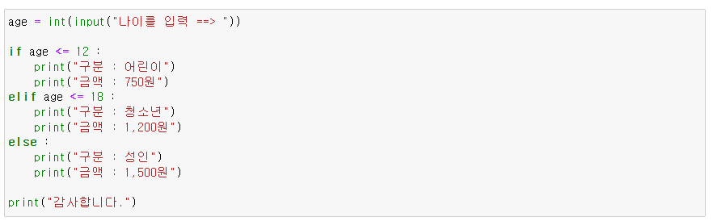

#### 영화 장르 분류

- 영화명: 킬링 로맨스, 장르: 코미디
- 영화명: 존윅4, 장르: 액션
- 영화명: 스즈메의 문단속, 장르: 애니메이션

```
액션장르입니다.
```

**접기/펼치기**

1.

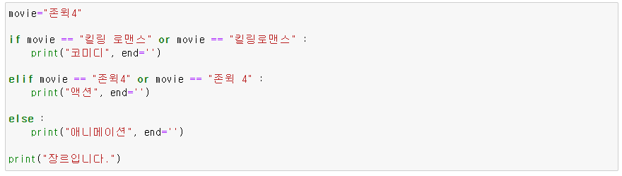

2.

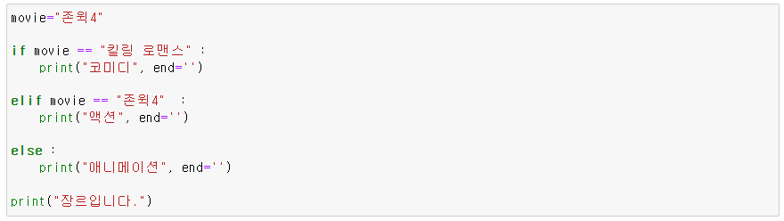

#### 문자열의 길이에 따른 분류

- len() 함수를 사용하여 문자열 길이를 세기

```python
text = input("문자열을 입력하세요==> ")

length = len(text)

if length < 3:
    print("짧은 문자열입니다.")
elif length < 5:
    print("중간 길이의 문자열입니다.")
else:
    print("긴 문자열입니다.")
```

```
문자열을 입력하세요==> 안
짧은 문자열입니다.
```

## PC방 나이 제한 검사하기

- PC방은 밤 10시가 넘으면 청소년은 출입할 수 없다.
- 밤 10시에 나이를 입력하고 출입 가능 여부를 체크하는 프로그램을 작성해보자

[figure not shown]

```
나이를 입력 ==> 5
집에 갈 시간이네요!
협조 감사합니다.
```

**접기/펼치기**

[figure not shown]

### 확인문제

[figure not shown]

**접기/펼치기**

1. X
2. O
3. O
4. X

[figure not shown]

### import 하지 않았을 경우 오류 발생

```python
random.randint(1,45)
```

```
---------------------------------------------------------------------------
NameError                                 Traceback (most recent call last)
Input In [1], in <cell line: 1>()
----> 1 random.randint(1,45)

NameError: name 'random' is not defined
```

### import 실행

- import란 파이썬에서 모듈 혹은 패키지를 가져오는 방법
- 다른 사람들이 만든 유용한 기능들을 우리의 코드에 활용할 수 있도록 가져오는 역할

```python
import random
```

[figure not shown]

### random.randint

- random 라이브러리에 들어 있는 randint라는 함수
- 주어진 값의 범위에서 임의의 숫자(정수)를 뽑아서 출력

```python
random.randint(1,46)
```

```
11
```

- 주사위 던지기

```python
min_num = 1
max_num = 6

dice_num = random.randint(min_num, max_num)

print("주사위 숫자 : ",dice_num)
```

```
주사위 숫자 :  1
```

### random.sample

- 1부터 45까지의 숫자 중에서 6개를 랜덤하게 뽑아서 출력
- 로또 추첨하기

```python
lotto = random.sample(range(1,46),6)
print("번호 :",lotto)
```

```
번호 : [34, 16, 40, 23, 36, 21]
```

### random.choice

- 주어진 여러개의 값 중 한가지 뽑아서 출력
- 식사 메뉴 고르기

```python
menu = "편의점","홍콩반점","봉구스밥버거","알촌","부대통령","흥이닭갈비"

menu_choice = random.choice(menu)

print("오늘의 점심 : ", menu_choice)
```

```
오늘의 점심 :  알촌
```

## 요약

1. 프로그램의 흐름은 세 가지로 구분된다.
   - 순차 구조 : 차례대로 진행되는 구조
   - 선택 구조 : 몇 가지 중 하나를 고르는 구조
   - 반복 구조 : 같은 내용을 여러 번 수행하는 구조
2. 조건식 if문이 참이라면 실행할 문장을 실행하고, 조건식이 거짓이라면 실행할 것이 없다.
3. if~else문은 조건식이 참이라면 문장1을 실행하고, 거짓이면 문장2를 실행한다.
4. 중첩 if문 (또는 중복 if문)은 if문을 한 번 실행하고, 그 결과에 다시 if문을 실행한다.
5. 중첩 if문을 사용할 때는 중간의 if~else문을 elif문으로 줄여서 사용할 수 있습니다.